# Lauder Placenta Microbiome Analysis

Benjamin J Callahan

7/13/2018

Comparison of placenta samples with contamination controls does not provide evidence for a distinct placenta microbiota, Lauder et al., 2016, https://doi.org/10.1186/s40168-016-0172-3.

Load needed packages:

```r
#load packages
packages <- c("decontam", "ggplot2", "reshape2", "phyloseq", "dada2", "gridExtra")
sapply(packages, require, character.only = TRUE)
```

```
##  decontam   ggplot2  reshape2  phyloseq     dada2 gridExtra
##      TRUE      TRUE      TRUE      TRUE      TRUE      TRUE
```

```r
#settings
theme_set(theme_bw())
options(stringsAsFactors = FALSE)
path.in <- "~/DecontamManuscript/Analyses/LauderPlacenta" # CHANGE ME

#color palettes
cbbPalette <- c("#E69F00", "#56B4E9", "#009E73", "#F0E442", "#0072B2", "#D55E00", "#CC79A7","#000000")
methodPalette <- c(Prevalence="turquoise3", Frequency="orangered1", Combined="darkorchid4")
prevalencePalette <- c("2" = "#edf8e9", "3-5" = "#bae4b3", "6-10" = "#74c476", "11+" = "#238b45")
```

## Process 16S Amplicon Data

This section analyzes the Lauder et al. placenta biopsy amplicon sequencing data: “The data set supporting the results of this article is available in the NCBI SRA repository, PRJNA309332 [https://www.ncbi.nlm.nih.gov/bioproject/PRJNA309332].”

Once downloaded, the amplicon sequencing data was processed using the dada2 R package, producing a table of exact amplicon sequence variants (ASVs). Those processed data objects are included as part of this reproducible analysis in the `LauderPlacenta` directory. In addition, the DADA2 processing steps are included here as well for completeness, but commented out:

```r
#path.fastq <- "~/Desktop/Contamination/Lauder"
#fns <- list.files(path.fastq, pattern="fastq.gz", full.names=TRUE) # Just forward reads?
## Filter and Trim
#plotQualityProfile(fns[1:3])
#filts <- file.path(path.fastq, "filtered", basename(fns))
#out <- filterAndTrim(fns, filts, maxEE=2, truncLen=260, multithread=TRUE)
#summary(out[,2]/out[,1]) # 98%+ passing
## Read in sample data
#df <- read.csv(file.path(path.fastq, "SraRunInfo.csv"), header=TRUE, stringsAsFactors = FALSE)
#names(filts) <- sapply(strsplit(basename(filts), "_"), `[`, 1)
#identical(df$Run, names(filts)) # TRUE
## Process
#drp <- derepFastq(filts, verbose=TRUE)
#names(drp) <- df$Run
#err <- learnErrors(drp, multithread=TRUE)
## pool=TRUE to go after even the rarest ASVs in the hunt for the placenta microbiome
#dd <- dada(drp, err=err, pool=TRUE, multithread=TRUE)
#sta <- makeSequenceTable(dd)
#dim(sta) # 69 7060 -> 69 7667
#st <- removeBimeraDenovo(sta, method="consensus", multithread=TRUE)
#dim(st); sum(st)/sum(sta) # 69 4644   0.9049186 -> 69 5469  0.9172217
#tax <- assignTaxonomy(st, "~/tax/silva_nr_v128_train_set.fa.gz", multithread=TRUE)
#save(df, sta, st, tax, file=file.path(path.in, "processed_plac.rda"))
```

## Analayze Data

Read in the ASV tables and taxonomies inferred by DADA2:

```r
load(file.path(path.in, "processed_plac.rda"))
ft <- sweep(st, 1, rowSums(st), "/")
```

Read in the sample metadata:

```r
samdf <- read.csv(file.path(path.in, "Biosamples.csv"), header=TRUE, stringsAsFactors = FALSE)
samdf <-samdf[match(df$BioSample, samdf$BioSample),]
rownames(samdf) <- df$Run
identical(samdf$BioSample, df$BioSample) # TRUE
```

```
## [1] TRUE
```

```r
identical(rownames(samdf), rownames(st)) # TRUE
```

```
## [1] TRUE
```

```r
table(samdf$Prep, samdf$BodySite)
```

```
##
##         Air Swab Extraction PlacentaFS PlacentaMS Saliva Sterile Swab
##   Mobio        5          6          6          6      6            5
##   PSP          6          2          6          6      6            3
##
##         Vaginal Swab
##   Mobio            0
##   PSP              6
```

```r
neg.sites <- c("Air Swab", "Extraction", "Sterile Swab")
plac.sites <- c("PlacentaFS", "PlacentaMS")
samdf$neg <- samdf$BodySite %in% neg.sites
samdf$plac <- samdf$BodySite %in% plac.sites
samdf$Type <- samdf$BodySite
samdf$Type[samdf$neg] <- "Negative"
samdf$Type[samdf$plac] <- "Placenta"
samdf$Reads <- rowSums(st)
```

Note that Vaginal Swab samples were only collected for the PSP kit, and not the Mobio kit.

Perform ordinations and look at the clustering by BodySite and by Prep (~ the kit used):

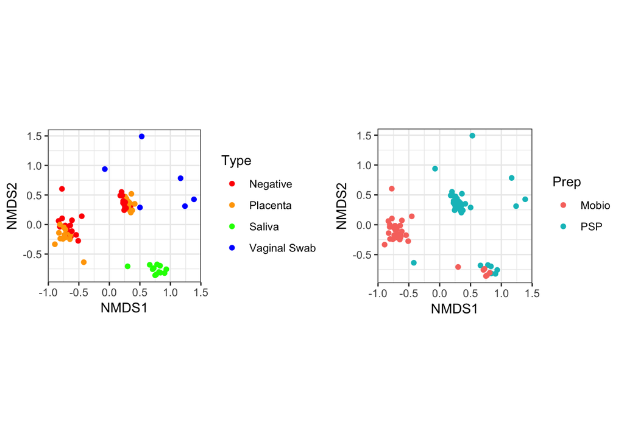

There are four clusters in the ordination: (1) Saliva samples, both kits, (2) Vaginal Swab samples, PSP kit, (3) Placenta/Control samples, Mobio kit, (4) Placenta/Control samples, PSP kit.

Taking a closer look at the negative controls:

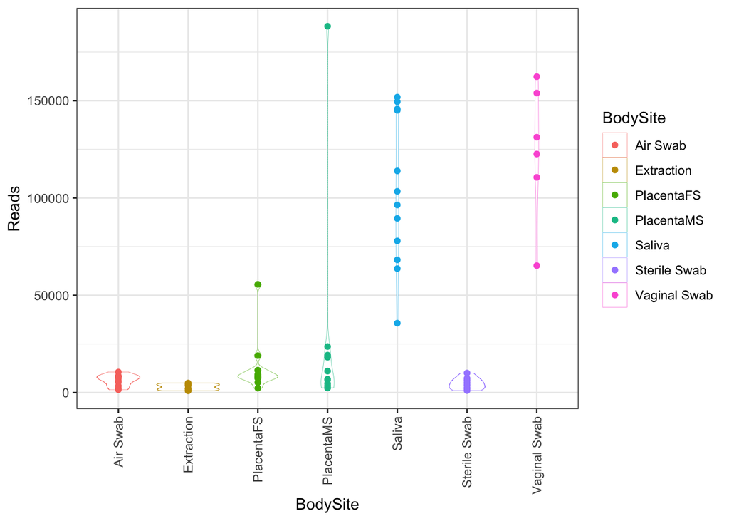

```
## Square root transformation
## Wisconsin double standardization
## *** Solution reached
```

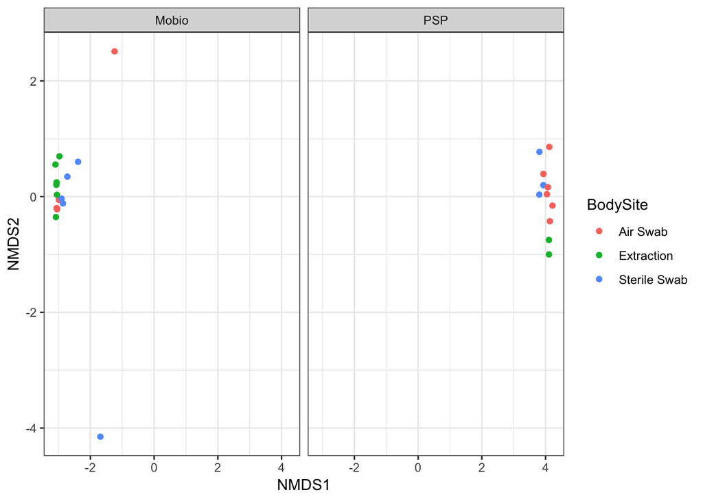

The distribution of read counts in negative controls is completly non-overlapping with the much greater distribution in vaginal/saliva samples. The placenta samples largely follow the air/sterils swab distribution, with a couple of high-read-count outliers. The negative controls totally separate by kit, and the different typers of negative controls are intermixed in ordinations. We’ll use them inerchangably.

## Look for non-contaminants

In this case, it is reasonable to simply pool the placenta/negatives across the kits. With more samples, independent processing would be better, but sample numbers are so low here, and the non-contaminants we are testing for are not kit dependent:

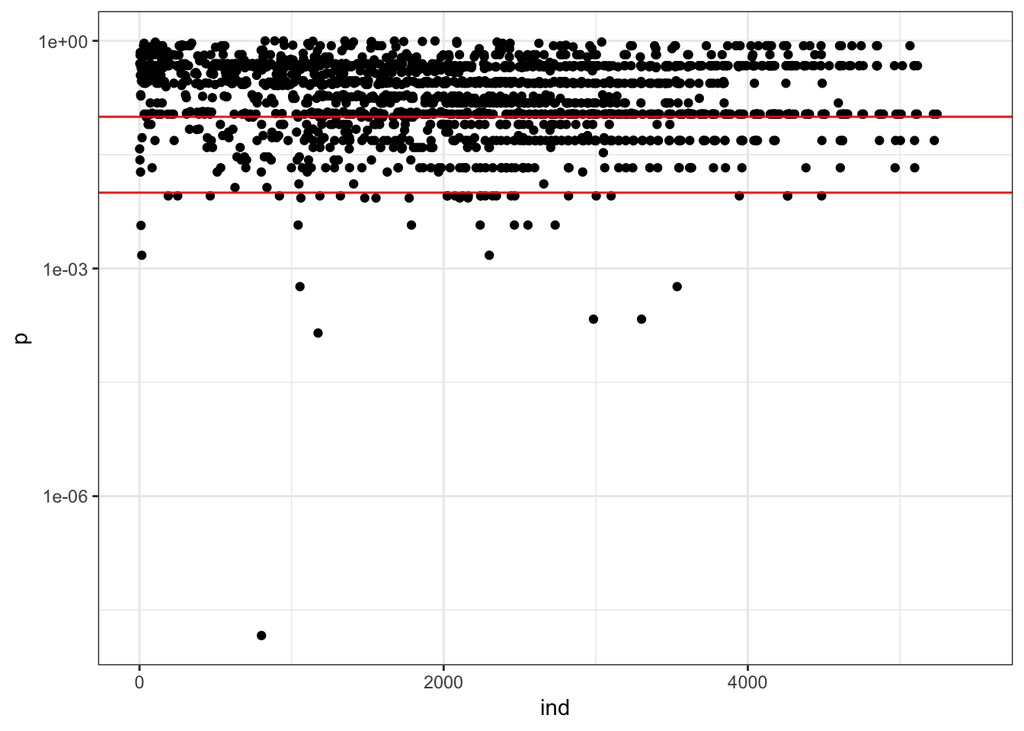

```r
out <- isNotContaminant(subset_samples(ps, neg | plac), neg="neg", method="prevalence", detailed=TRUE)
out$ind <- seq(nrow(out))
ggplot(data=out, aes(x=ind, y=p)) + geom_point() + scale_y_log10() + geom_hline(yintercept=0.1, color="red") + geom_hline(yintercept=0.01, color="red") + theme_bw()
```

```r
summary(out$p)
```

```
##    Min. 1st Qu.  Median    Mean 3rd Qu.    Max.    NA's
##   0.000   0.108   0.195   0.280   0.471   1.000    3556
```

```r
sum(out$p < 0.1, na.rm=TRUE); sum(out$p < 0.01, na.rm=TRUE); sum(p.adjust(out$p)<0.5, na.rm=TRUE)
```

```
## [1] 411
```

```
## [1] 46
```

```
## [1] 4
```

So 46 have a raw score (which is a p-value here since this is the prevalence method) of less than 0.01, and if we want an FDR < 50% we only get 4 hits. It’s worth requiring a higher total prevalence here though to somewhat lessen the multiple-hypothesis burden:

```r
out5 <- out[out$prev>=5,]
out5$p.adjust <- p.adjust(out5$p)
dim(out5);sum(out5$p.adjust<0.5)
```

```
## [1] 810   8
```

```
## [1] 6
```

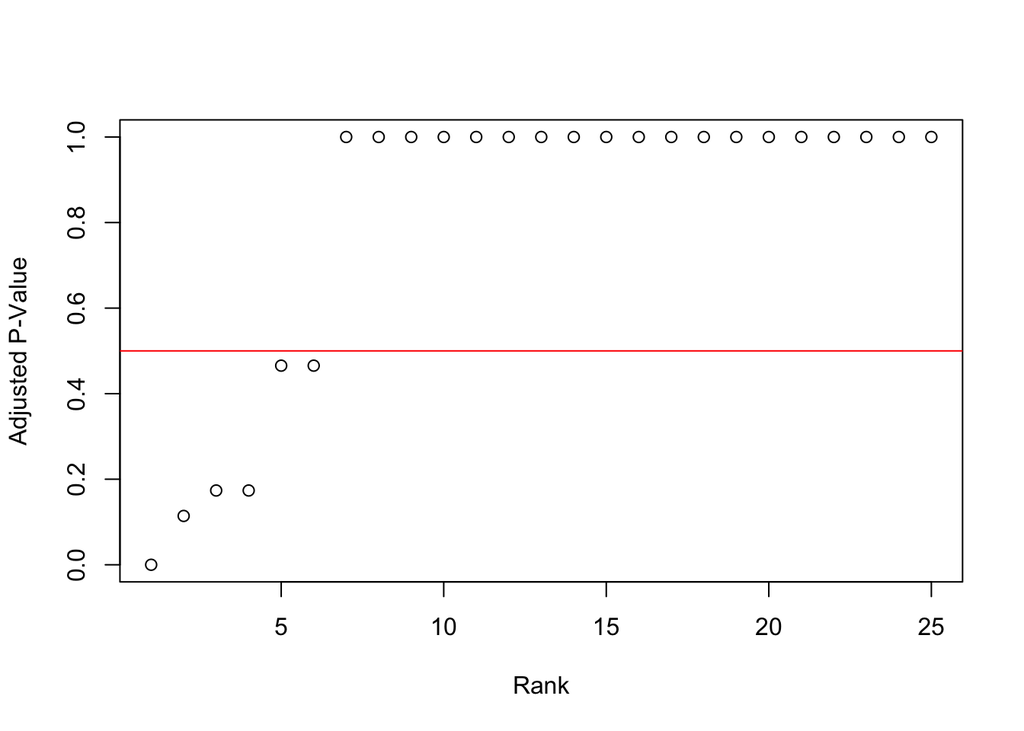

```r
plot(sort(out5$p.adjust)[1:25], ylab="Adjusted P-Value", xlab="Rank")
abline(0.5, 0, col="red")
```

```r
# save 2.6x3 in PDF
```

So there are 6 “believable” hits if using an FDR cutoff. Let’s just go ahead and annotate the top 20:

```r
sq20 <- rownames(out5)[order(out5$p)[1:20]]
anndf <- data.frame(Padjusted = out5[sq20,"p.adjust"],
                    Kingdom = tax[sq20,"Kingdom"], Genus = tax[sq20,"Genus"],
                    Placenta=colSums(st[samdf$Type == "Placenta",sq20]>0),
                    Negative=colSums(st[samdf$Type == "Negative",sq20]>0),
                    Saliva=colSums(st[samdf$Type == "Saliva",sq20]>0),
                    Vagina=colSums(st[samdf$Type == "Vaginal Swab",sq20]>0))

rownames(anndf) <- NULL
anndf
```

```
##       Padjusted   Kingdom                         Genus Placenta Negative
## 1  0.0000118023 Eukaryota                          <NA>       19        0
## 2  0.1141456713 Eukaryota                          <NA>       11        0
## 3  0.1736283311 Eukaryota                          <NA>        9        0
## 4  0.1736283311 Eukaryota                          <NA>        9        0
## 5  0.4654711246  Bacteria Ruminococcaceae_NK4A214_group        8        0
## 6  0.4654711246 Eukaryota                          <NA>        8        0
## 7  1.0000000000  Bacteria                 Streptococcus        7        0
## 8  1.0000000000  Bacteria                 Lactobacillus        7        0
## 9  1.0000000000  Bacteria                 Lactobacillus        8        1
## 10 1.0000000000  Bacteria                          <NA>        6        0
## 11 1.0000000000  Bacteria                          <NA>        6        0
## 12 1.0000000000  Bacteria                          <NA>        6        0
## 13 1.0000000000  Bacteria                  Prevotella_9        6        0
## 14 1.0000000000  Bacteria   Rikenellaceae_RC9_gut_group        6        0
```

[output cut: 27 more lines]

And use [BLAST against nt as well](https://blast.ncbi.nlm.nih.gov/Blast.cgi?PROGRAM=blastn&PAGE_TYPE=BlastSearch&LINK_LOC=blasthome), excluding environmental and unculturables:

From the BLAST results (most annotations are from 100% identity and 100% coverage hits)….

1. Homo sapiens
2. Homo sapiens
3. Homo sapiens
4. Homo sapiens
5. uncult Ruminococcaceae
6. Homo sapiens
- *THIS THE FDR 50% STOPPING POINT*

## Conclusions

There is a pretty clean story here. At the FDR<0.5 cutoff, 5/6 of the “significant” non-contaminants are human DNA. This demonstrates the method is working, non-target human DNA is indeed a non-contaminant, i.e. it is truly present in the placental samples. However, it also demonstrates that there is little to no evidence for a placenta microbiome here, at least a core microbiome that is common across placental environments, as spuriously amplified human DNA is (almost) all we are finding.